# HCAHPS Impact on Patient Outcomes within United States Hospitals

Nick Stadler

## **Introduction**

Hospital Consumer Assessment of Healthcare Providers and Systems (HCAHPS) is a survey sent out to discharged adult patients after a stay in an acute care hospital. This survey is requested of the patient between 2 days to 6 weeks post discharge and asks the patient to rate on a scale of 1-5, 5 being the best, various questions relating to their stay to gauge their experience. Questions pertain to the responsiveness of the staff, cleanliness of the facility, communication, and other aspects regarding how the patient feels their experience was while admitted. Patients are selected at random for this survey, and are not limited to Medicare beneficiaries. These scores are submitted to the Centers for Medicaid and Medicare Services (CMS) and taken into account for incentive payments to acute care hospitals under the Inpatient Prospective Payment System and the Hospital Value-Based Purchasing program.

The objective of this report is to ascertain if better patient outcomes are related to higher HCAHPS scores.

Data has been cleaned using SQL to remove facilities that are outside the 50 states, as well as those run by the United States military and Veterans Affairs.

### Facility Info

In total 4,585 acute care facilities across all 50 states and Washington D.C. reported at least some data to CMS that is used in this report. The distribution of facilities is shown in the graph below. The data is taken from patient interactions within each facility from July 1st, 2022 through June 30th, 2023. CMS data dictionary for these databases can be found [HERE](https://data.cms.gov/provider-data/dataset/dgmq-aat3#data-dictionary).

| Count | state |
| --- | --- |
| 386 | TX |
| 327 | CA |
| 181 | FL |
| 173 | IL |
| 160 | OH |
| 158 | PA |
| 154 | NY |
| 131 | KS |
| 130 | MI |
| 129 | GA |

[output cut: 41 more lines]

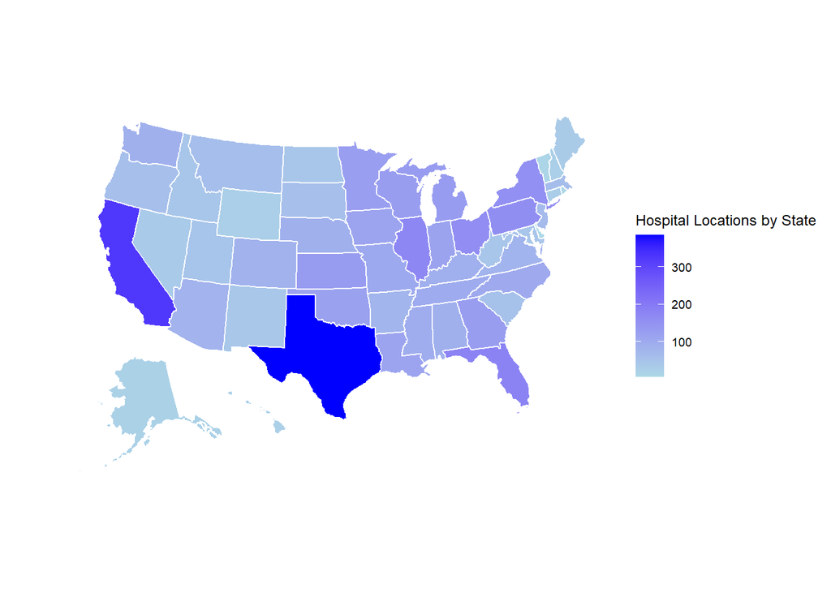

## **Analysis**

### HCAHPS compared to MORT-30 Outcomes

HCAHPS scores from each facility are averaged to provide an overall score and then plotted against varying aspects of care to find any relationship of how the patient views care and the result of their care.

The following is an analysis of the relationship of HCAHPS scores and patient outcomes. Outcomes in this report are measured based upon 30 day mortality (MORT-30) rates in the categories of Acute Myocardial Infarction (AMI), Heart Failure (HF), Pneumonia (PN), Chronic Obstructive Pulmonary Disorder (COPD), and Coronary Artery Bypass Graft (CABG). This information is provided from the acute care hospital for stays between July 1st, 2022 through June 30th, 2023. All data is obtained from the Centers for Medicare & Medicaid Services https://data.cms.gov/provider-data/search.

[output not shown]

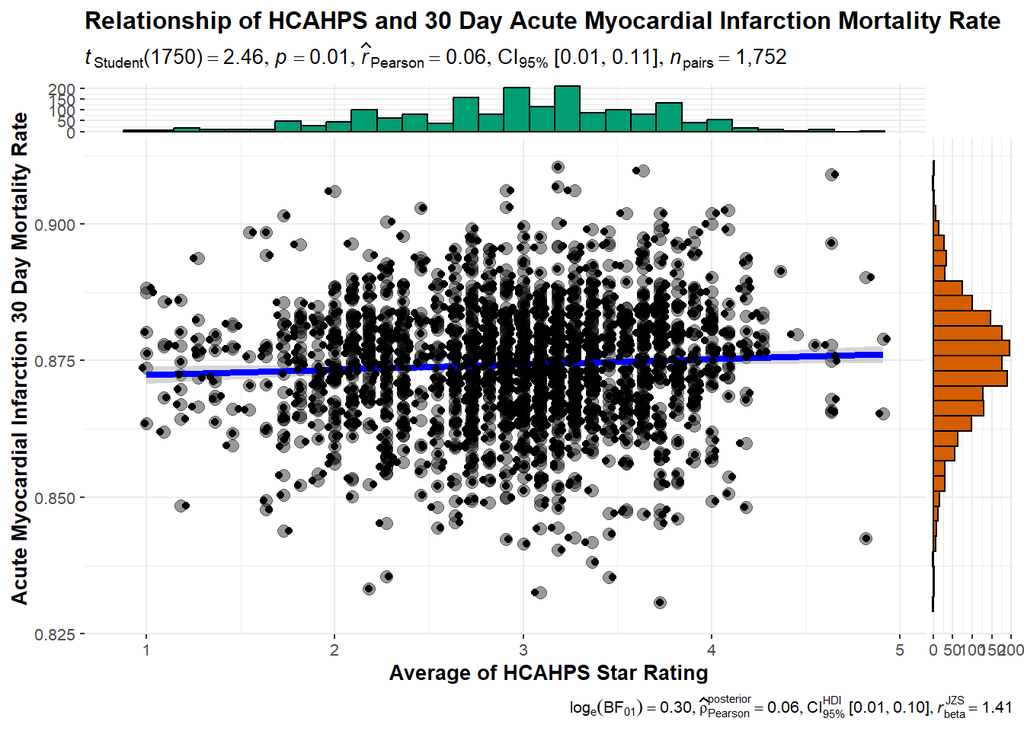

```
##  Facility.ID        MORT.30.AMI.Performance.Rate   AVG.Stars
##  Length:1752        Min.   :0.8307               Min.   :1.000
##  Class :character   1st Qu.:0.8674               1st Qu.:2.545
##  Mode  :character   Median :0.8748               Median :3.000
##                     Mean   :0.8742               Mean   :2.964
##                     3rd Qu.:0.8813               3rd Qu.:3.455
##                     Max.   :0.9105               Max.   :4.909
##  HCAHPS_Fac_ID
##  Length:1752
##  Class :character
##  Mode  :character
##
##
##
```

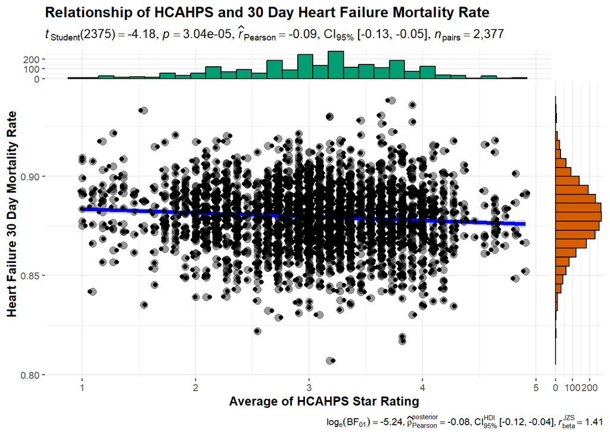

```
##  Facility.ID        MORT.30.HF.Performance.Rate   AVG.Stars
##  Length:2377        Min.   :0.8072              Min.   :1.000
##  Class :character   1st Qu.:0.8691              1st Qu.:2.636
##  Mode  :character   Median :0.8799              Median :3.091
##                     Mean   :0.8795              Mean   :3.059
##                     3rd Qu.:0.8904              3rd Qu.:3.636
##                     Max.   :0.9380              Max.   :4.909
##  HCAHPS_Fac_ID
##  Length:2377
##  Class :character
##  Mode  :character
##
##
##
```

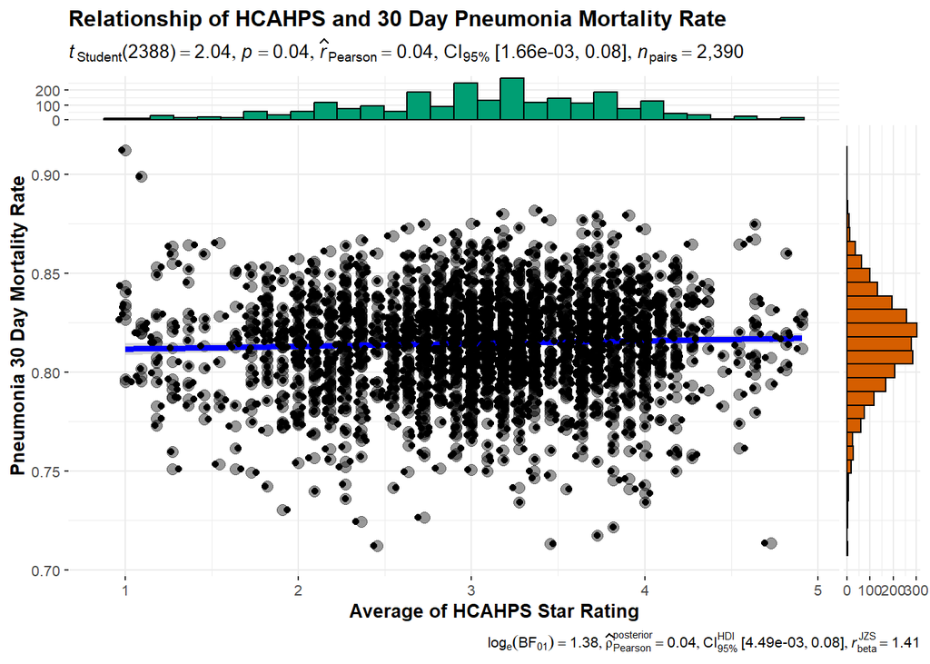

```
##  Facility.ID        MORT.30.PN.Performance.Rate   AVG.Stars
##  Length:2390        Min.   :0.7120              Min.   :1.000
##  Class :character   1st Qu.:0.8003              1st Qu.:2.636
##  Mode  :character   Median :0.8157              Median :3.091
##                     Mean   :0.8144              Mean   :3.058
##                     3rd Qu.:0.8298              3rd Qu.:3.636
##                     Max.   :0.9122              Max.   :4.909
##  HCAHPS_Fac_ID
##  Length:2390
##  Class :character
##  Mode  :character
##
##
##
```

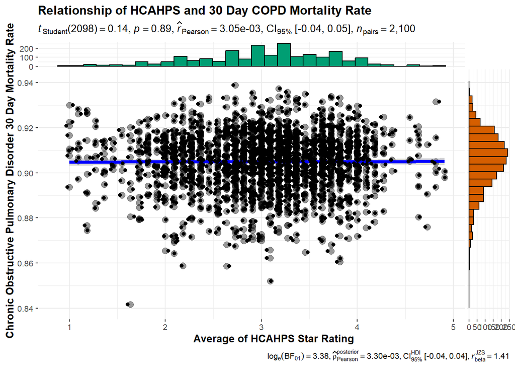

```
##  Facility.ID        MORT.30.COPD.Performance.Rate   AVG.Stars
##  Length:2100        Min.   :0.8416                Min.   :1.000
##  Class :character   1st Qu.:0.8974                1st Qu.:2.636
##  Mode  :character   Median :0.9059                Median :3.091
##                     Mean   :0.9049                Mean   :3.026
##                     3rd Qu.:0.9137                3rd Qu.:3.545
##                     Max.   :0.9389                Max.   :4.909
##  HCAHPS_Fac_ID
##  Length:2100
##  Class :character
##  Mode  :character
##
##
##
```

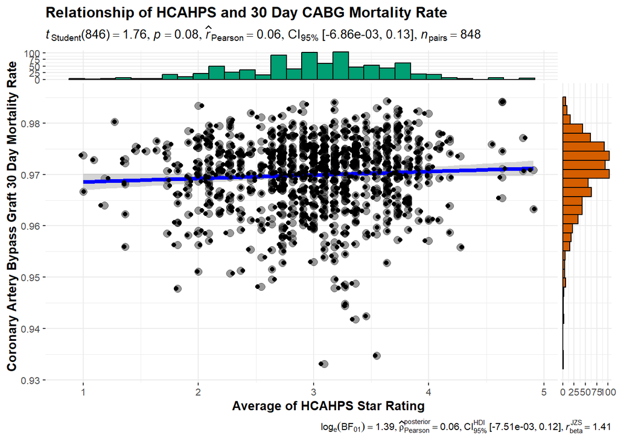

```
##  Facility.ID        MORT.30.CABG.Performance.Rate   AVG.Stars
##  Length:848         Min.   :0.9331                Min.   :1.000
##  Class :character   1st Qu.:0.9660                1st Qu.:2.636
##  Mode  :character   Median :0.9710                Median :3.000
##                     Mean   :0.9699                Mean   :2.998
##                     3rd Qu.:0.9747                3rd Qu.:3.455
##                     Max.   :0.9843                Max.   :4.909
##  HCAHPS_Fac_ID
##  Length:848
##  Class :character
##  Mode  :character
##
##
##
```

### HCAHPS Compared to Healthcare Associated Infections

With very low Pearson correlation coefficient values on each of the MORT-30 outcomes, further examination was done by comparing HCAHPS scores to Healthcare Associated Infections (HAI). HAI are grouped into 6 categories HAI 1-6 and correlate to central-line associated bloodstream infections (CLABSI), catheter-associated urinary tract infections (CAUTI), surgical site infection (SSI) from colon surgery, SSI from abdominal hysterectomy, Methicillin-resistant *Staphylococcus aureus* (MRSA), and *Clostridium difficile* (C.diff) infections respectively. HAI Performance Rates are calculated by the number of observed infections for that category divided by the number of predicted infections for that category, therefore, lower performance rate is better.

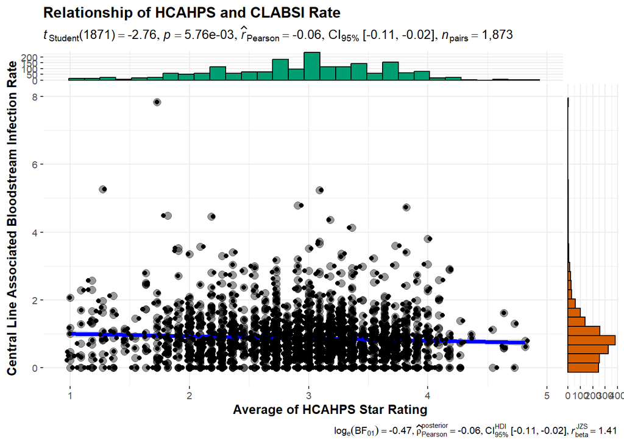

```
##  Facility.ID        HAI.1.Performance.Rate   AVG.Stars     HCAHPS_Fac_ID
##  Length:1873        Min.   :0.0000         Min.   :1.000   Length:1873
##  Class :character   1st Qu.:0.3840         1st Qu.:2.545   Class :character
##  Mode  :character   Median :0.7560         Median :3.000   Mode  :character
##                     Mean   :0.8648         Mean   :2.933
##                     3rd Qu.:1.1600         3rd Qu.:3.364
##                     Max.   :7.8320         Max.   :4.818
```

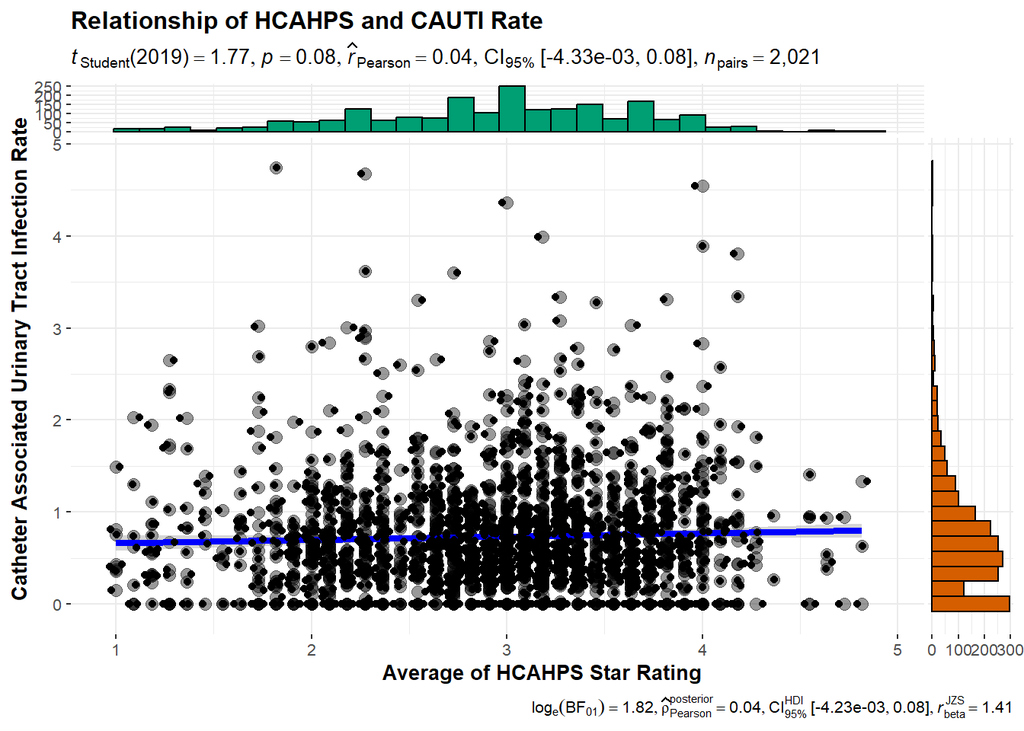

```
##  Facility.ID        HAI.2.Performance.Rate   AVG.Stars     HCAHPS_Fac_ID
##  Length:2021        Min.   :0.0000         Min.   :1.000   Length:2021
##  Class :character   1st Qu.:0.3090         1st Qu.:2.545   Class :character
##  Mode  :character   Median :0.6150         Median :3.000   Mode  :character
##                     Mean   :0.7293         Mean   :2.953
##                     3rd Qu.:0.9820         3rd Qu.:3.455
##                     Max.   :4.7390         Max.   :4.818
```

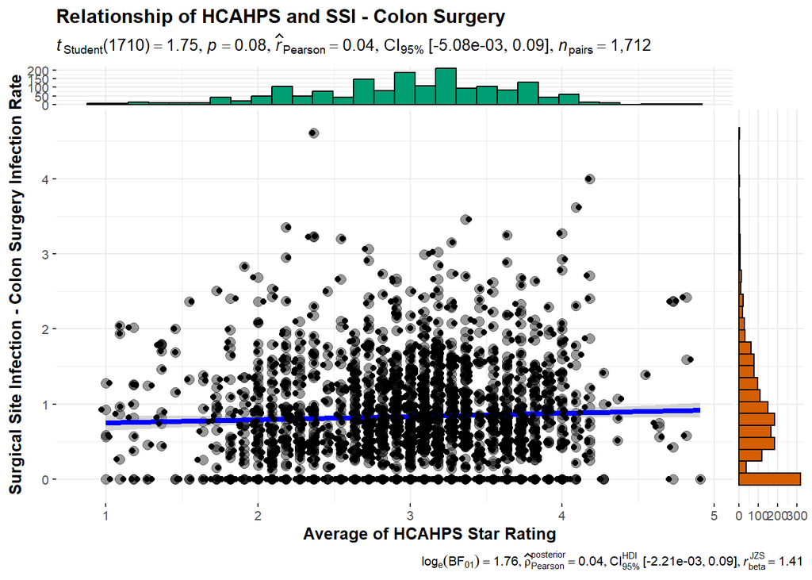

```
##  Facility.ID        HAI.3.Performance.Rate   AVG.Stars     HCAHPS_Fac_ID
##  Length:1712        Min.   :0.0000         Min.   :1.000   Length:1712
##  Class :character   1st Qu.:0.3545         1st Qu.:2.545   Class :character
##  Mode  :character   Median :0.7490         Median :3.091   Mode  :character
##                     Mean   :0.8336         Mean   :2.988
##                     3rd Qu.:1.2190         3rd Qu.:3.455
##                     Max.   :4.6040         Max.   :4.909
```

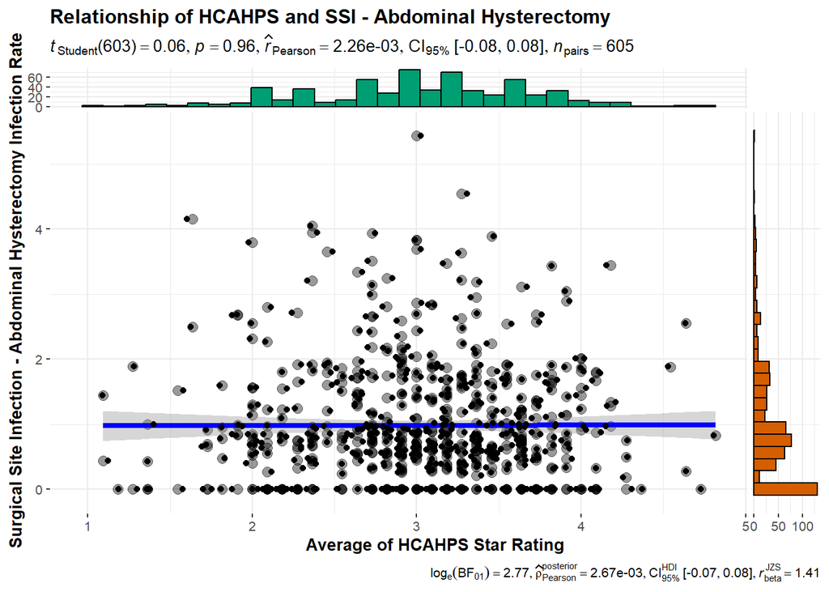

```
##  Facility.ID        HAI.4.Performance.Rate   AVG.Stars     HCAHPS_Fac_ID
##  Length:605         Min.   :0.0000         Min.   :1.091   Length:605
##  Class :character   1st Qu.:0.3210         1st Qu.:2.636   Class :character
##  Mode  :character   Median :0.7670         Median :3.091   Mode  :character
##                     Mean   :0.9793         Mean   :3.019
##                     3rd Qu.:1.4620         3rd Qu.:3.455
##                     Max.   :5.4280         Max.   :4.818
```

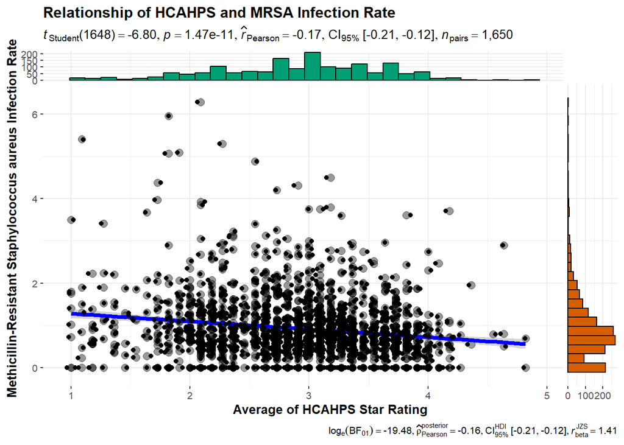

```
##  Facility.ID        HAI.5.Performance.Rate   AVG.Stars     HCAHPS_Fac_ID
##  Length:1650        Min.   :0.0000         Min.   :1.000   Length:1650
##  Class :character   1st Qu.:0.4530         1st Qu.:2.455   Class :character
##  Mode  :character   Median :0.7870         Median :3.000   Mode  :character
##                     Mean   :0.9244         Mean   :2.906
##                     3rd Qu.:1.2408         3rd Qu.:3.364
##                     Max.   :6.2790         Max.   :4.818
```

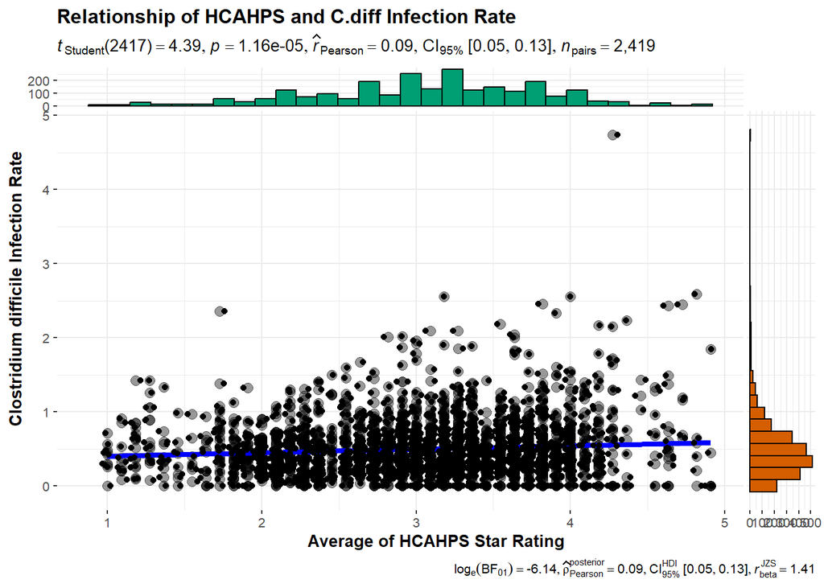

```
##  Facility.ID        HAI.6.Performance.Rate   AVG.Stars     HCAHPS_Fac_ID
##  Length:2419        Min.   :0.0000         Min.   :1.000   Length:2419
##  Class :character   1st Qu.:0.2380         1st Qu.:2.636   Class :character
##  Mode  :character   Median :0.4280         Median :3.091   Mode  :character
##                     Mean   :0.4951         Mean   :3.058
##                     3rd Qu.:0.6605         3rd Qu.:3.636
##                     Max.   :4.7360         Max.   :4.909
```

### HCAHPS Compared to Readmissions

With HCAHPS scoring not showing a strong link with MORT-30 outcomes or HAI, the relationship between HCAHPS and readmission ratios was explored. Readmission ratios (calculated by predicted readmission / expected readmission, lower is better) for each category of AMI, HF, PN, COPD, and CABG were averaged for each facility and plotted against the average HCAHP score.

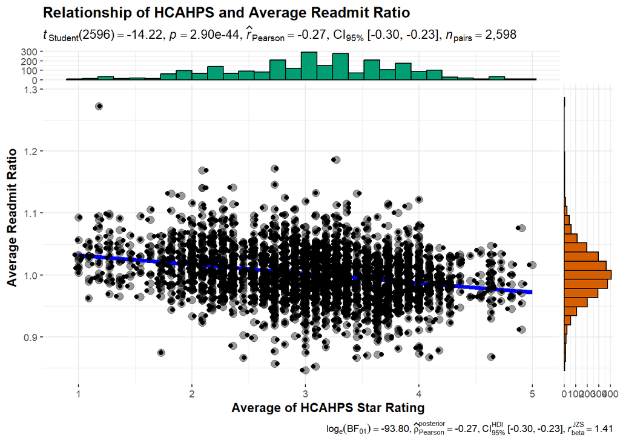

```
##  Facility.ID        AVG_Readmit_Ratio   AVG.Stars     HCAHPS_Fac_ID
##  Length:2598        Min.   :0.8461    Min.   :1.000   Length:2598
##  Class :character   1st Qu.:0.9751    1st Qu.:2.636   Class :character
##  Mode  :character   Median :1.0001    Median :3.091   Mode  :character
##                     Mean   :1.0012    Mean   :3.067
##                     3rd Qu.:1.0263    3rd Qu.:3.636
##                     Max.   :1.2726    Max.   :5.000
```

This correlation does show the strongest relationship of any others explored in this report, however, it does not show a strong definitive relationship of higher HCAHPS score related to lower readmission rate.

## **Conclusion**

Based upon this data, there does not seem to be a strong relationship between HCAHPS scoring and outcomes, hospital acquired infections, or readmission rates after a hospital stay for the categories mentioned for the time frame this data was provided. More research is needed to find how a patient views their care and how the result of their care can be related to help overall outcomes, and properly incentive acute care facilities for the care in which they provide.